# Search and Rescues on the Adirondacks

Kristina Franklin, Rosie Delwiche, Connor Hathaway, Jackie Budka

# 1 Introduction

The observed data is concerning the amount of rescues within New York State. Specifically, the rescues within the Adirondack mountains will be considered. The concerned variables are amount of rangers, amount of people being rescued, age and gender of rescued, and the type of activity that caused the accident. This data is interesting because it can be used to find if certain groups of people should be getting extra safety training before entering the Adirondack Forest.

…

# 2 Background

The data set came from Data World, which got the original data from the New York State Government. The data is an observational study being completed by the search and rescue rangers.

by analyzing this data, we hope to find correlations between the types of rescues performed, and who was being rescued, in the Adirondacks. This will help decide if different people should have more, less, or different safety training before adventuring on their own.

…

# 3 Methods and Results

Summarize data. Use both numerical and graphical summaries.

The two plots below are created from location of the rescues within New York State. Looking at the plot of the entire state, there are two regions where rescues occur more frequently, the high peaks being the larger area of concentration. Because of this concentration, a second plot was made to focus on the rescues within the Adirondack mountains.

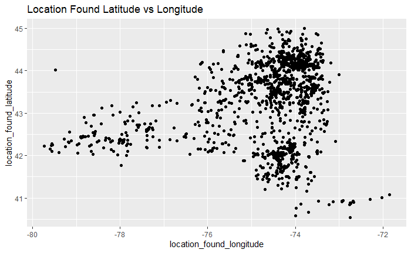

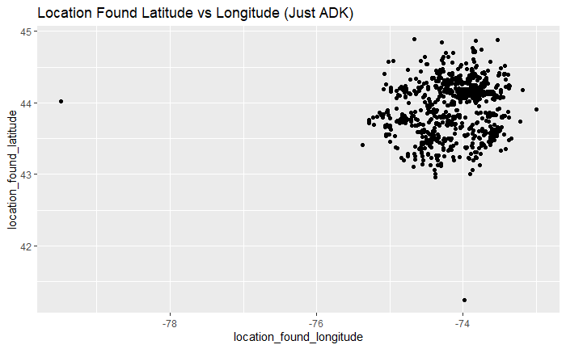

The data has many different variables and presented to us in a large confusing table. The following code sorts the variables we are interested in, and creates a small table for each one.

As you can see, there is more chainsaw then flood victims.

```
        F    M
   6  827 1245

Fugitive Search        Recovery          Rescue          Search
              2              60             902            1114

            Aircraft               Biking              Boating              Camping             Chainsaw    Climbing:Rock/Ice
                   8                   12                  133                   60                    3                   35
            Criminal           Despondent              Fishing         Flood Victim               Hiking     Horseback riding
                   4                   20                   18                    1                 1512                    2
             Hunting        Motor vehicle Off road vehicle/ATV              Runaway               Skiing           Snowmobile
                  74                    6                   16                   17                   23                   63
            Stranded             Swimming              Walking           Whitewater
                   3                   26                   40                    2
```

```
Mean ages
Recovery=  50.8
Rescue=  39.83433
Search=  35.26649
```

```r
mean(y$incident_time_elapsed)

search <- y %>%
  filter(response_type=="Search")
rescue <- y %>%
  filter(response_type=="Rescue")
recovery <- y %>%
  filter(response_type=="Recovery")

rev <- mean(search$incident_time_elapsed, na.rm = "TRUE")
res <- mean(rescue$incident_time_elapsed, na.rm = "TRUE")
sea <- mean(recovery$incident_time_elapsed, na.rm = "TRUE")
cat('Mean incident time elapsed
Recovery= ',rev)
cat('
Rescue= ',res)
cat('
Search= ',sea)
```

[output not shown]

Perform at least one relevant hypothesis test.

Two hypothesis tests were performed

The second hypothesis test performed was a single-tailed hypothesis to see if the ages between rescued males and females differ.  
The null hypothesis is mu_f - mu_m = 0 The alternative hypothesis is mu_f - mu_m < 0 The t-test is performed to find the difference between the two samples. After the t-test is run, the value is -3.176, meaning we reject the null hypothesis because the difference between males and females is not 0.

```
    Welch Two Sample t-test

data:  female$subject_age and male$subject_age
t = -3.176, df = 1828.6, p-value = 0.0007591
alternative hypothesis: true difference in means is less than 0
95 percent confidence interval:
      -Inf -1.281465
sample estimates:
mean of x mean of y
 36.05625  38.71582
```

```r
# Does the mean case time differ between search and rescue?
t.test(search$incident_time_elapsed,rescue$incident_time_elapsed,alternative = "two.sided",conf.level = .98)

# Does the mean case time differ between recovery and search?
t.test(recovery$incident_time_elapsed,search$incident_time_elapsed,alternative = "two.sided",conf.level = .98)
```

[output not shown]

```r
incident_model <- lm(incident_time_elapsed~number_of_rangers_involved, data = y)
incident_model
# intercept 1206.5
# slope 624.2
# this means predicted time = 624.2 * rangers involved
```

```r
#y %>% ggplot(aes(x = number_of_rangers_involved, y = incident_time_elapsed)) +
#  geom_point() +
#  geom_abline(intercept = 3.257e+00, slope = 8.195e-06 )
#incident_model$residuals
sum(incident_model$residuals^2)
summary(incident_model)

# Because p is less than alpha, we reject the null hypothesis. We have reason to believe that there is a linear relationship between incident time elapsed and number of rangers involved
```

[output not shown]

Check the various assumptions of for statistical tests.

[output not shown]

[figure not shown]

[figure not shown]

[figure not shown]

[figure not shown]

```r
# predict the time to close a case with 3 rangers
predict(incident_model, newdata = data.frame(number_of_rangers_involved = 3))

# correlation between time elapsed and number of rangers for all types of incidents
y %>%
  ggplot(aes(x = incident_time_elapsed, y = number_of_rangers_involved, color = response_type)) +
  geom_point(size = 0.1) +
  facet_wrap(vars(response_type))

# looking at correlation for each response type
# there is a high correlation between time elapsed and number of rangers involved for fugitive search
# the other ones dont show a high correlation but this is kinda expected because there are lots of outliers
y %>%
  group_by(response_type) %>%
  summarize(r = cor(incident_time_elapsed, number_of_rangers_involved, use = "complete.obs"))


# incident model qq plot
plot(incident_model)
```

[output not shown]

For the linear regression analysis, interpret coefficients and/or make relevant predictions and summarize their meaning.

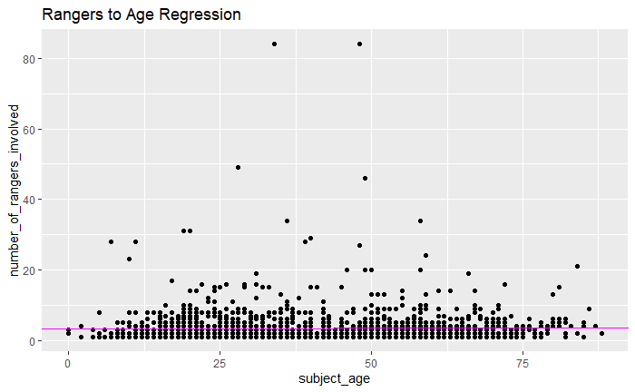

[output not shown]

```
Call:
lm(formula = number_of_rangers_involved ~ subject_age, data = raw_adk_data)

Residuals:
   Min     1Q Median     3Q    Max
-2.536 -2.207 -1.240  0.590 80.700

Coefficients:
            Estimate Std. Error t value Pr(>|t|)
(Intercept) 3.142535   0.219316  14.329   <2e-16 ***
subject_age 0.004627   0.005212   0.888    0.375
---
Signif. codes:  0 ‘***’ 0.001 ‘**’ 0.01 ‘*’ 0.05 ‘.’ 0.1 ‘ ’ 1

Residual standard error: 4.39 on 2006 degrees of freedom
  (70 observations deleted due to missingness)
Multiple R-squared:  0.0003927, Adjusted R-squared:  -0.0001056
F-statistic: 0.7882 on 1 and 2006 DF,  p-value: 0.3748
```

```r
raw_adk_data %>%
  group_by(response_type) %>%
  summarize(r = cor(x = subject_age, y = number_of_rangers_involved, use = "complete.obs"))
```

| response_type | r |
| --- | --- |
| Fugitive Search | NA |
| Recovery | -0.24168254 |
| Rescue | 0.01852403 |
| Search | 0.03228901 |

```r
cor(raw_adk_data$subject_age,raw_adk_data$number_of_rangers_involved, use = "complete.obs")
```

…

# 4 Conclusions

…

# References

Data.world https://data.world/data-ny-gov/u6hu-h7p5